# Practical Machine Learning Project

Joel Carlson

Monday, September 15, 2014

Several devices, such as *Jawbone Up*, *Fitbit* and*Nike FuelBand* allow a user to capture data about personal activity. In this writeup, data from such devices will be examined. Users of the devices were asked to perform excercises using several different methods, classed as **A**, **B**, **C**, **D** and **E** in the dataset.

The goal of this analysis is to use a supervised learning algorithm to predict which of these methods was used based on data from the sensors.

An explanation of the variables can be found [here](http://groupware.les.inf.puc-rio.br/har)

## Data Preparation

The first step of the analysis is to load appropriate libraries, set a seed for reproducibility, and import the data:

```r
library(caret)

library(GGally)

set.seed(333)
# Download data
training.url <- "https://d396qusza40orc.cloudfront.net/predmachlearn/pml-training.csv"
training.file <- "pml-training.csv"



pml.training <- read.csv(training.file, stringsAsFactors=FALSE)
```

A summary of the data should be examined: (output not shown)

```r
summary(pml.training)
```

From which we found that there are many variables which contain incomplete data. To remove these a function was written to:

-Replace blanks with `NA`s

-Remove any column with greater than 20 `NA`s

```r
Rem.NAs <- function(dat){
    dat[dat == ""] <- NA
    for(i in ncol(dat):1){
        if(length(which(is.na(dat[,i]))) >= 20){
                dat <- dat[,-i]
        }
    }
    dat
}

#run function on training data
pml.training <- Rem.NAs(pml.training)

#confirm there are no more NAs
length(which(is.na(pml.training)))
```

```
## [1] 0
```

There were also several columns which are not related to prediction:

- “X”
- “raw_timestamp_part_1”
- “raw_timestamp_part_2”
- “cvtd_timestamp”
- “new_window”
- “num_window”

Which are removed, and the `classe` column coerced to a factor for predictions:

```r
pml.training <- pml.training[,-which(names(pml.training) %in% c("X", "raw_timestamp_part_1",
                                    "raw_timestamp_part_2", "cvtd_timestamp",
                                    "new_window", "num_window"))]


pml.training$classe <- as.factor(pml.training$classe)
```

```r
inTrain <- createDataPartition(y=pml.training$classe, p=0.05, list=FALSE)
training <- pml.training[inTrain,]
testing <- pml.training[-inTrain,]
```

## Algorithms

### Generalized Boost Method

The variable `classe` is being predicted using all the other available variables:

```r
fitgbm <- train(classe ~ ., data=training, method="gbm", verbose=FALSE)

predgbm <- predict(fitgbm, testing)
```

Examine prediction accuracy:

```r
testing$predRight <- predgbm==testing$classe
table(predgbm, testing$classe)
```

```
##
## predgbm    A    B    C    D    E
##       A 5087  231   21   28   42
##       B  101 2988  202   18  180
##       C   16  232 2893  252  100
##       D   66   28   94 2615  140
##       E   31  128   40  142 2964
```

### Random Forest

The next algorithm used was a random forest method, again from the caret package:

```r
fitrf <- train(classe ~ ., data=training, method="rf")


predrf <- predict(fitrf, testing)
```

And examine the output:

```r
testing$predRight <- predrf==testing$classe
table(predrf, testing$classe)
```

```
##
## predrf    A    B    C    D    E
##      A 5149  241   13   34    4
##      B   34 3048  187   29   95
##      C   16  238 2930  206  112
##      D   61   49   96 2685   69
##      E   41   31   24  101 3146
```

To improve the prediction a four fold cross validation option was added:

```r
fitrf <- train(classe ~ ., data=training, method="rf", trControl = trainControl(method="cv", number=4))

predrf <- predict(fitrf, testing)
```

And examined:

```r
testing$predRight <- predrf==testing$classe
table(predrf, testing$classe)
```

```
##
## predrf    A    B    C    D    E
##      A 5138  230   10   33    5
##      B   30 3026  190   24   84
##      C   14  257 2937  213  114
##      D   68   50   87 2671   70
##      E   51   44   26  114 3153
```

### Final Analysis

The data was re-partitioned so the algorithm took into account more of the data, and a new model was trained:

```r
inTrain <- createDataPartition(y=pml.training$classe, p=0.7, list=FALSE)
training <- pml.training[inTrain,]
testing <- pml.training[-inTrain,]

fitrf <- train(classe ~ ., data=training, method="rf", trControl = trainControl(method="cv", number=4))
```

The final results:

```r
predrf <- predict(fitrf, testing)
testing$predRight <- predrf==testing$classe
table(predrf, testing$classe)
```

```
##
## predrf    A    B    C    D    E
##      A 1673    6    0    0    0
##      B    0 1130    6    1    1
##      C    1    3 1016    4    0
##      D    0    0    4  958    4
##      E    0    0    0    1 1077
```

```r
print(fitrf)
```

```
## Random Forest
##
## 13737 samples
##    53 predictor
##     5 classes: 'A', 'B', 'C', 'D', 'E'
##
## No pre-processing
## Resampling: Cross-Validated (4 fold)
##
## Summary of sample sizes: 10302, 10303, 10304, 10302
##
## Resampling results across tuning parameters:
##
##   mtry  Accuracy  Kappa  Accuracy SD  Kappa SD
##    2    1         1      0.001        0.001
##   29    1         1      0.002        0.003
##   57    1         1      0.005        0.006
##
## Accuracy was used to select the optimal model using  the largest value.
## The final value used for the model was mtry = 29.
```

The final model has near perfect accuracy on the artificial test data fold.

Let’s apply it to the actual test data:

```r
#Load data
testing.url <- "https://d396qusza40orc.cloudfront.net/predmachlearn/pml-testing.csv"

testing.file <- "pml-testing.csv"

pml.testing <- read.csv(testing.file, stringsAsFactors=FALSE)

#Remove NAs and Blanks
pml.testing <- Rem.NAs(pml.testing)

#Remove irrelevant variables
pml.testing <- pml.testing[,-which(names(pml.testing) %in% c("X", "raw_timestamp_part_1",
                                    "raw_timestamp_part_2", "cvtd_timestamp",
                                    "new_window", "num_window"))]

#Predict using our model
predfinal <- predict(fitrf, pml.testing)
testing$predRight <- predrf==testing$classe
```

Here I have omitted the results of the prediction so as not to foster plagiarism in the answers, however this model achieved 18/20 correct answers.

## Errors and Miscellaneous

Just for fun, in the final model we can see which variables contributed the most to the variability in the dataset. This could be used in the future for dimensionality reduction to speed up computation time. The caret package has a function for this: `varImp`

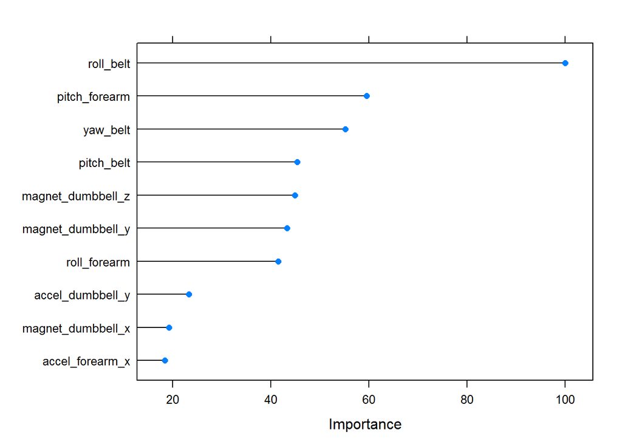

```r
fitVar <- varImp(fitrf)
#Plot the top 10 contributors:
plot(fitVar,10)
```

Let’s examine the relationship between several of the top contributors. Values related to the `belt` are presented here, colored by the class of movement:

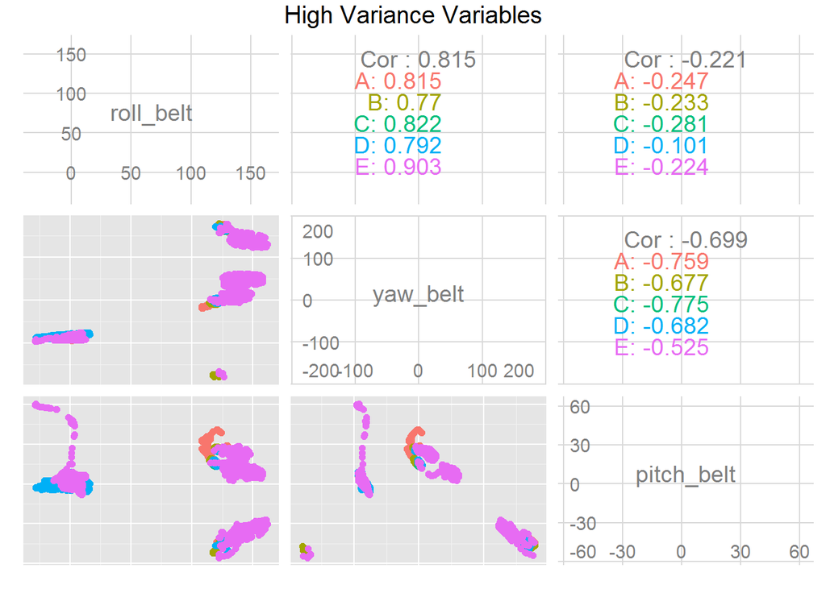

```r
ggpairs(data=training,
        columns=c("roll_belt", "yaw_belt", "pitch_belt"), title="High Variance Variables", colour = "classe")
```